# R package Least Cost Path: formulating least cost path analyses

Joseph Lewis

2019-12-08

# 1. Introduction

This vignette describes **leastcostpath**, a package written for use in the R environment (R Core Team, 2016). It provides functionality to calculate Least Cost Paths using multiple cost functions that approximate the difficulty of moving across a landscape, taking into account obstacles and local fricion (e.g. slope). Furthermore, this package allows for the incorporation of cost when traversing across slope, as well as other factors such as landscape feature attraction.

# 2. Background

This example will aim to reconstruct the location of a known Roman road (Margary 130) in Roman Britain. The Margary 130 Roman road ran from Benenden to Canterbury and was the eastward branch from the ironworking districts in the Weald, South East England (Margary, 1973).

Built in the early 3rd century (Cleere, 1981), the road offered land-borne transportation to Canterbury, passing through two ironworking sites at Ashford (Lawrie, 2004) and WestHawk Farm, Ashford (Swat Archaeology, 2010).

The computed LCPs in each iteration will be assessed via the validate_lcp function.

# 3. Setup

```r
library(rgdal) # used to read shapefiles
library(rgeos) # used for spatial operations (e.g. buffering)
library(sp) # used for creation of spatial objects
library(raster) # used for raster analysis
library(leastcostpath) # used for least cost path analysis
library(elevatr) # used to download elevation data for study area
library(magrittr) # used for pipes
library(ggplot2) # used for producing chart to show model comparison
```

```r
# location of Roman road downloaded from http://romanroadsinbritain.info/data.html (Bishop, 2014).
road <- rgdal::readOGR("D:/R projects/leastcostpath/margary 130.shp", verbose = FALSE)
```

```r
elevation <- elevatr::get_elev_raster(locations = road, z = 11, src = "aws")

elevation <- raster::crop(elevation, c(575116.3, 624332.3, 123620, 167169.2))

# OS Open Rivers map including freshwater rivers, tidal estuaries and canals. Downloaded from https://www.ordnancesurvey.co.uk/business-government/products/open-map-rivers
water <- rgdal::readOGR("D:/R projects/Roman Roads Network/data/WatercourseLink.shp", verbose = FALSE)

#water <- raster::crop(water, c(577241.4, 623510.7, 123620, 167169.2))
water <- raster::crop(water, elevation)

# filter to permanent rivers within the study area
water <- water[grep(c("Great Stour|River"), water$name1),]

# Identify where the road intersects with rivers
water_intersections <- rgeos::gIntersection(road, water)

water_intersections <- rgeos::gBuffer(water_intersections, width = res(elevation)[1] * 8)

# remove the intersection points from the rivers - this is to create gaps in the rivers to ensure that the LCP is able to reach the destination
water <- rgeos::gDifference(water, water_intersections)
```

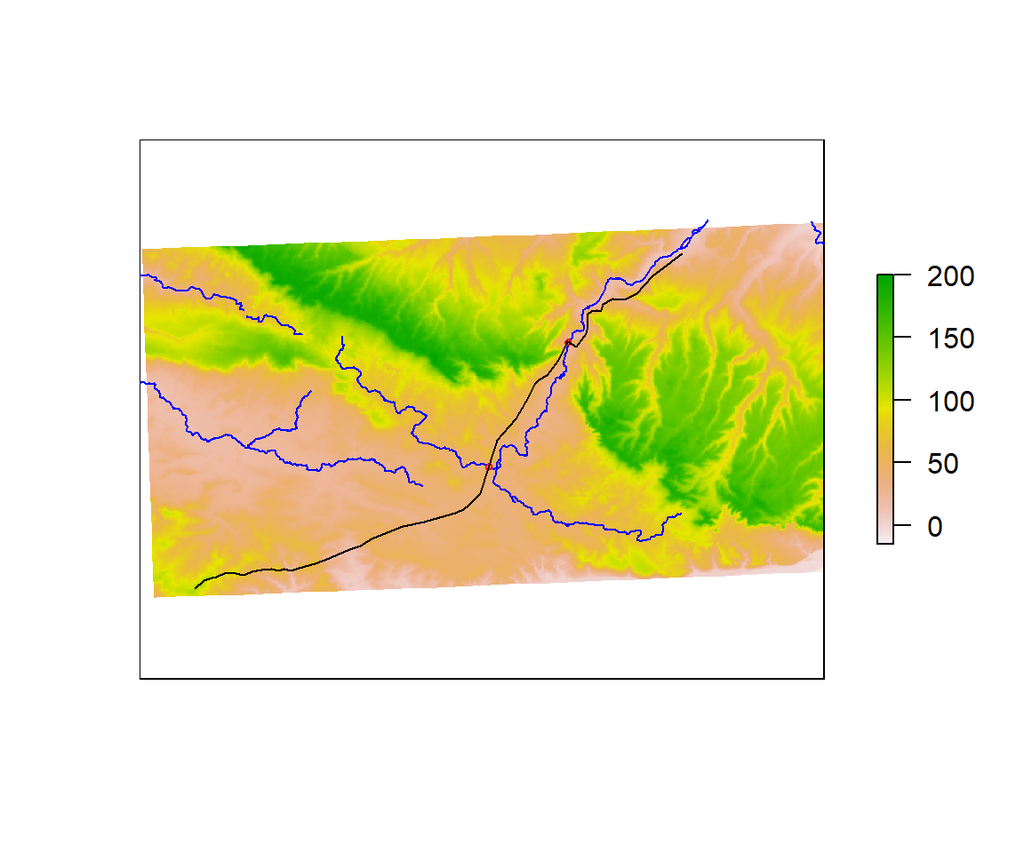

```r
plot(elevation, bty="n", xaxt="n", yaxt="n")
plot(water, add = T, col = "blue")
plot(water_intersections, add = T, border = "red")
plot(road, add = T, col = "black")
```

```r
# buffer rivers before rasterizing - this is to ensure that the river's width is enough to stop the LCP from crossing
water <- rgeos::gBuffer(water, width = res(elevation)[1] * 6)

water_r <- raster::rasterize(x = water, y = elevation)

water_r[water_r == 1] <- 0

water_r[is.na(water_r)] <- 1
```

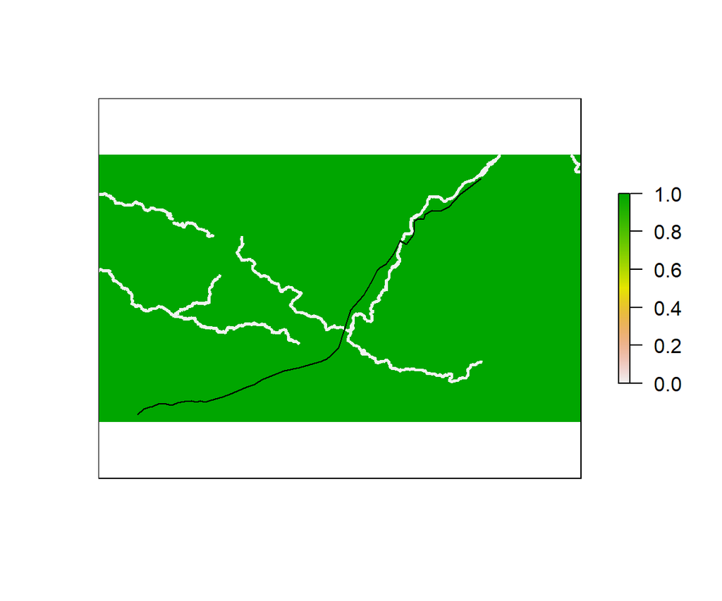

```r
plot(water_r, bty="n", xaxt="n", yaxt="n")
plot(road, add = T)
```

# 4. Slope only

```r
cs <- leastcostpath::create_slope_cs(dem = elevation, cost_function = 'modified tobler', neighbours = 16) %>%
  "*" (gdistance::transition(x = water_r, transitionFunction = max, directions = 16,symm=TRUE))
```

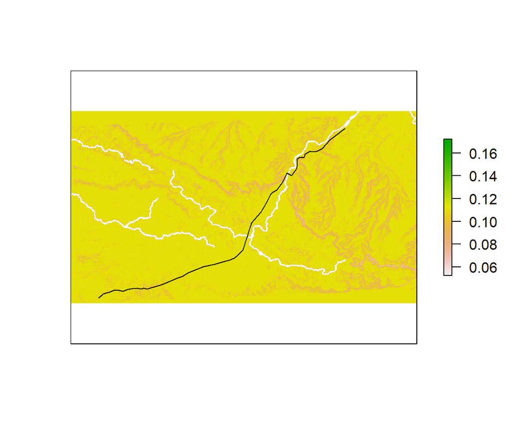

```r
plot(raster(cs), bty="n", xaxt="n", yaxt="n")
plot(road, add = T)
```

```r
# convert the road to Spatialpoints in order to identify the origin and destination of the road
crds <- coordinates(as(road, 'SpatialPoints'))

loc1 <- rbind(crds[1, ])
loc1 = sp::SpatialPoints(loc1)

loc2 <- rbind(crds[nrow(crds), ])
loc2 = sp::SpatialPoints(loc2)

westhawk <- sp::SpatialPoints(cbind(600000, 139900), proj4string = crs(road))

# Due to directional = TRUE, the LCP will only be computed from the origin to the destination. This is done as the direction of intended movement is believed to be from the ironworking districts in the Weald to Canterbury in the north-east of the study area.

# If the direction of movement is not known, it is suggested to set directional = FALSE. This will then compute the LCP from the origin to the destination and vice-versa, with the results stored in a list.
lcp <- leastcostpath::create_lcp(cost_surface = cs, origin = loc1, destination = loc2, directional = TRUE)
```

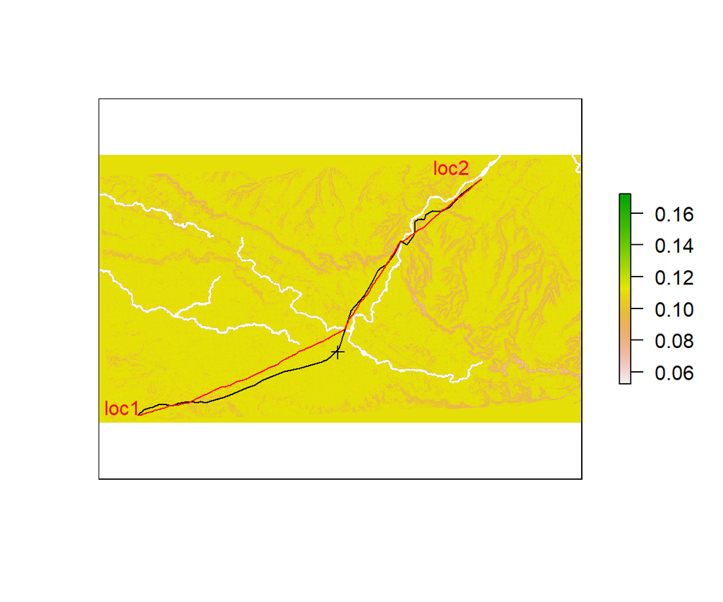

```r
plot(raster(cs), bty="n", xaxt="n", yaxt="n")
plot(road, add = T)
plot(westhawk, add = T)
plot(lcp[[1]], add = T, col = "red")
text(loc1@coords[1]-1500, loc1@coords[2]+800, "loc1", col = "red")
text(loc2@coords[1]-3000, loc2@coords[2]+1200, "loc2", col = "red")
```

```r
val1 <- validate_lcp(lcp = lcp[[1]], comparison = road, buffers = c(30, 90, 150, 300, 600, 900))

val1$model <- "A_to_B"

val1
```

```
##     ID Buffer_Applied_from_data Percent_LCP_within_Distance  model
## 1 1  1                       30                        8.38 A_to_B
## 2 1  2                       90                       21.09 A_to_B
## 3 1  3                      150                       33.16 A_to_B
## 4 1  4                      300                       46.99 A_to_B
## 5 1  5                      600                       61.94 A_to_B
## 6 1  6                      900                       77.60 A_to_B
```

We can see that the computed LCP from Benenden to Canterbury does not cross Westhawk Farm. This suggests that the decision for the Roman road to pass Westhawk Farm was driven by factors other than topographical.

To ensure that the computed LCP Westhawk Farm crosses Westhawk Farm, we can do one of the following:

- Calculate two LCPs - one from Benenden to Westhawk Farm and one from Westhawk Farm to Canterbury. This forces the LCP to cross the Westhawk Farm but tells us little about its importance in the landscape.
- Calculate one LCP from Benenden to Canterbury, whilst including Westhawk Farm as a feature of attraction. This allows us to better understand Westhawk Farm’s importance in the landscape by modifying the attraction (rank) of the feature and its distance of attraction.

# 5. Including Westhawk Farm as a LCP destination/origin

```r
lcp2 <- leastcostpath::create_lcp(cost_surface = cs, origin = loc1, destination = westhawk, directional = TRUE)
lcp3 <- leastcostpath::create_lcp(cost_surface = cs, origin = westhawk, destination = loc2, directional = TRUE)

lcp3 <- rbind(lcp2[[1]], lcp3[[1]])

lcp3 <- gLineMerge(lcp3)
```

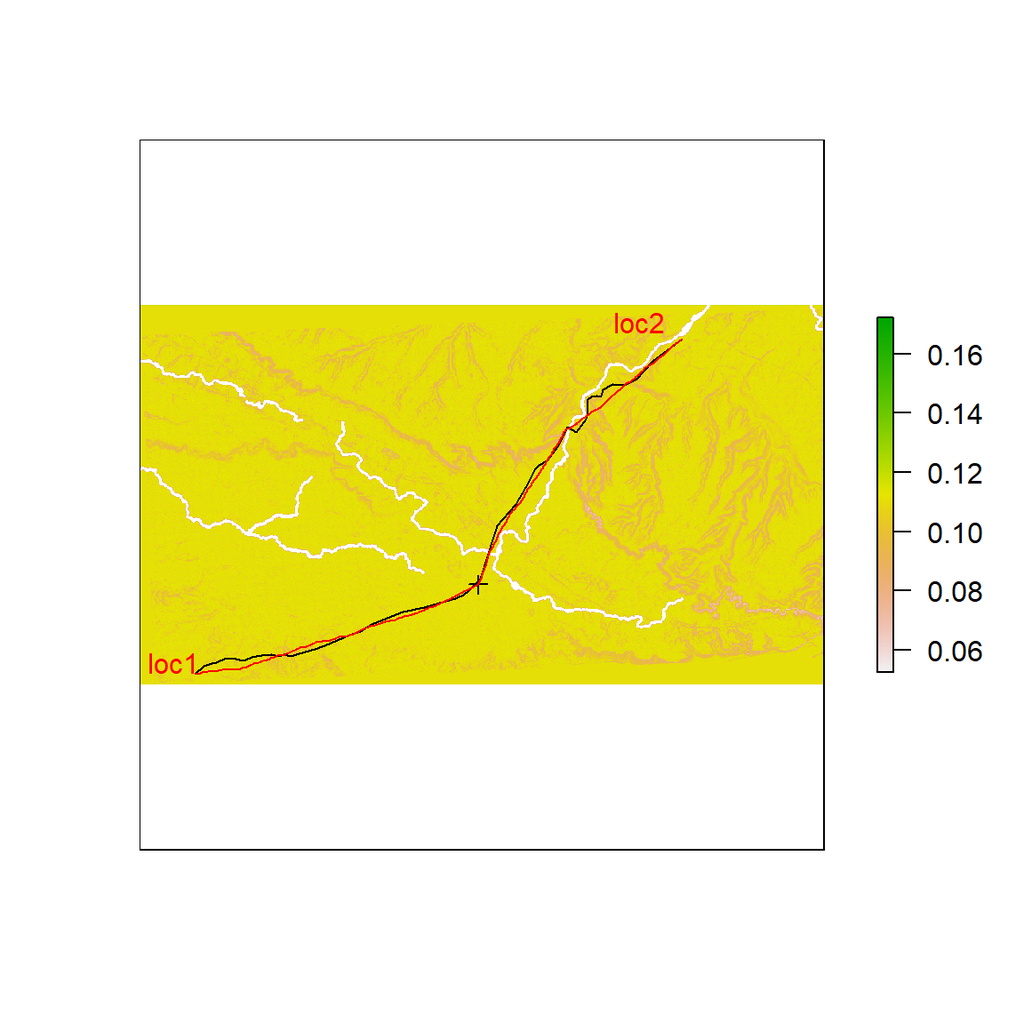

```r
plot(raster(cs), bty="n", xaxt="n", yaxt="n")
plot(road, add = T)
plot(westhawk, add = T)
plot(lcp3, add = T, col = "red")
text(loc1@coords[1]-1500, loc1@coords[2]+800, "loc1", col = "red")
text(loc2@coords[1]-3000, loc2@coords[2]+1200, "loc2", col = "red")
```

```r
val2 <- validate_lcp(lcp = lcp3, comparison = road, buffers = c(30, 90, 150, 300, 600, 900))

val2$model <- "A_to_B_to_C"
val2
```

```
##     ID Buffer_Applied_from_data Percent_LCP_within_Distance       model
## 1 1  1                       30                        11.7 A_to_B_to_C
## 2 1  2                       90                        31.6 A_to_B_to_C
## 3 1  3                      150                        45.5 A_to_B_to_C
## 4 1  4                      300                        68.5 A_to_B_to_C
## 5 1  5                      600                        92.6 A_to_B_to_C
## 6 1  6                      900                       100.0 A_to_B_to_C
```

# 6. Including Westhawk Farm as a Landscape Feature of Attraction

The feature attraction function is controlled by three arguments:

- max_attraction = rank of the feature
- distance = maximum distance that the feature is attractive (distances over the maximum distance have no effect on the ‘pull’ of the feature)
- eq = The decay rate of the feature attraction - linear or exponential

Combinations of these arguments will need to be assessed to see which produce the LCP that most closely matches with the location of the Margary 130 Roman road.

```r
cs2 <- cs %>%
  "*" (leastcostpath::create_feature_attraction(dem = elevation, locs = westhawk, max_attraction = 40, distance = 16000, eq = "exponential"))
```

```
## note: create_feature_attraction expects planar coordinates
```

```r
lcp4 <- leastcostpath::create_lcp(cost_surface = cs2, origin = loc1, destination = loc2, directional = TRUE)
```

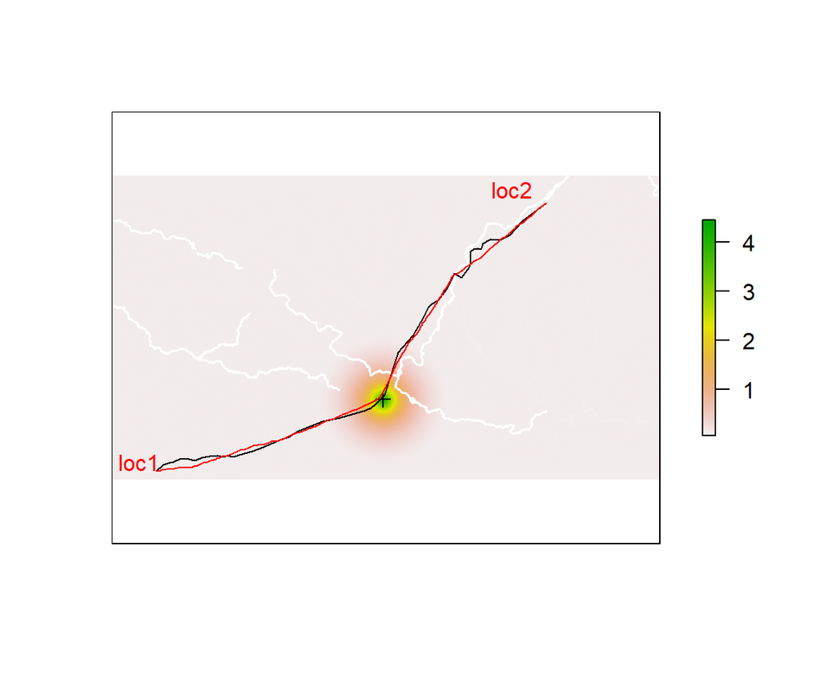

```r
plot(raster(cs2), bty="n", xaxt="n", yaxt="n")
plot(road, add = T)
plot(westhawk, add = T)
plot(lcp4[[1]], add = T, col = "red")
text(loc1@coords[1]-1500, loc1@coords[2]+800, "loc1", col = "red")
text(loc2@coords[1]-3000, loc2@coords[2]+1200, "loc2", col = "red")
```

```r
val3 <- validate_lcp(lcp = lcp4[[1]], comparison = road, buffers = c(30, 90, 150, 300, 600, 900))

val3$model <- "A_to_B_la"

val3
```

```
##     ID Buffer_Applied_from_data Percent_LCP_within_Distance     model
## 1 1  1                       30                        12.5 A_to_B_la
## 2 1  2                       90                        27.8 A_to_B_la
## 3 1  3                      150                        42.7 A_to_B_la
## 4 1  4                      300                        67.0 A_to_B_la
## 5 1  5                      600                        92.5 A_to_B_la
## 6 1  6                      900                       100.0 A_to_B_la
```

# 6. Model Comparison

```r
comparison <- rbind(val1, val2, val3)

comparison
```

```
##      ID Buffer_Applied_from_data Percent_LCP_within_Distance       model
## 1 1   1                       30                        8.38      A_to_B
## 2 1   2                       90                       21.09      A_to_B
## 3 1   3                      150                       33.16      A_to_B
## 4 1   4                      300                       46.99      A_to_B
## 5 1   5                      600                       61.94      A_to_B
## 6 1   6                      900                       77.60      A_to_B
## 1 11  1                       30                        11.7 A_to_B_to_C
## 2 11  2                       90                        31.6 A_to_B_to_C
## 3 11  3                      150                        45.5 A_to_B_to_C
## 4 11  4                      300                        68.5 A_to_B_to_C
## 5 11  5                      600                        92.6 A_to_B_to_C
## 6 11  6                      900                       100.0 A_to_B_to_C
## 1 12  1                       30                        12.5   A_to_B_la
## 2 12  2                       90                        27.8   A_to_B_la
## 3 12  3                      150                        42.7   A_to_B_la
## 4 12  4                      300                        67.0   A_to_B_la
## 5 12  5                      600                        92.5   A_to_B_la
## 6 12  6                      900                       100.0   A_to_B_la
```

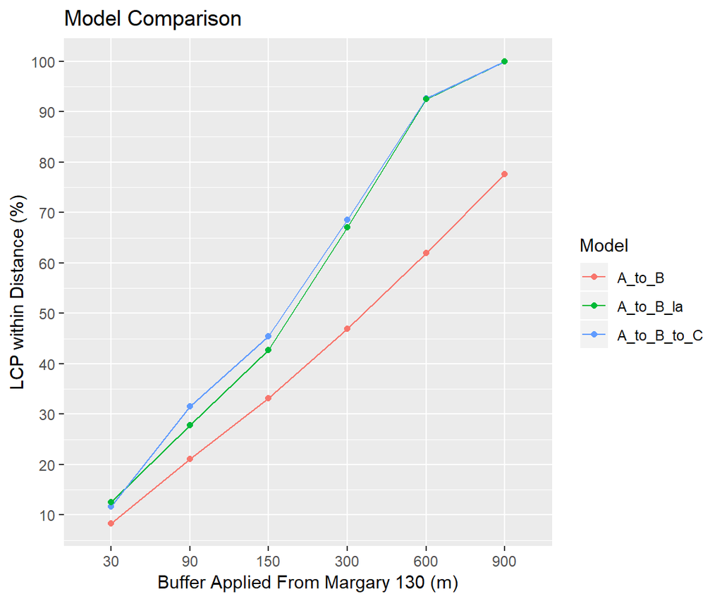

```r
ggplot(comparison, aes(x = as.factor(Buffer_Applied_from_data), y = as.numeric(Percent_LCP_within_Distance), colour = model, group = model)) +
  geom_line() +
  geom_point() +
  labs(title = "Model Comparison", x = "Buffer Applied From Margary 130 (m)", y = "LCP within Distance (%)", colour = "Model") +
  scale_y_continuous(breaks=seq(0,100,10))
```

By comparing models, we can see which model best reconstructs the Margary 130 Roman road. In this case, the LCP model from Benenden to Canterbury with Westhawk Farm as a destination produced the most accurate reconstruction.

It is worthwhile to note that although the LCP produced with Westhawk as a landscape feature was not the most accurate, the max attraction and distance arguments used in the create_feature_attraction function were not optimally chosen. It may well be that modifying these two arguments result in a more accurate prediction.

# 7. Conclusion

This example has shown the application of the R package **leastcostpath** in the reconstruction of the location of a known Roman road in Roman Britain.

It has demonstrated how **leastcostpath** aids in the LCP process and provides multiple functionalites when conducting LCP analyses.

# 8. References

Cleere, H.F (1981) The Iron Industry of Roman Britain. Unpublished PhD. Thesis. London University. Available at: http://www.wealdeniron.org.uk/HCleereThesis.pdf [Accessed 06 December 2019].

Lawrie, L. (2004) Ashford: A History & Celebration. Salisbury: Frith Book Company Ltd.

Margary, I.D. (1973) Roman Roads in Britain. London: John Baker.

R Core Team (2016). R: A Language and Environment for Statistical Computing. R Foundation for Statistical Computing. Vienna, Austria.

Swat Archaeology. (2010) Knoll Lane, Ashford, Kent: Archaeological Desk-Based Assessment. Available at: http://www.swatarchaeology.co.uk/pdf/2010/15a.%20Knoll%20Lane-final.pdf [Accessed 06 December 2019].